# Fuzzy Landscapes - A reproducible approach to analyse uncertain parameters

Wolfgang Hamer & Daniel Knitter

19 September 2018

# Exemplary Aim

- Identify potential vegetation cover around ukrainian mega-site of Maidanetske (3850-3700 BCE) under different climatic conditions

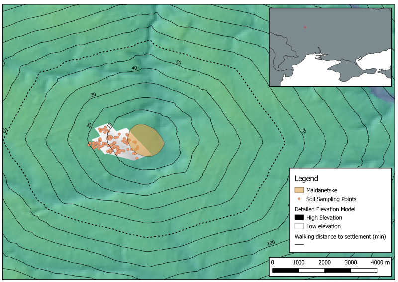

# Potential vegetation

- Identification of potential vegetation by application of adapted Ellenberg Diagram

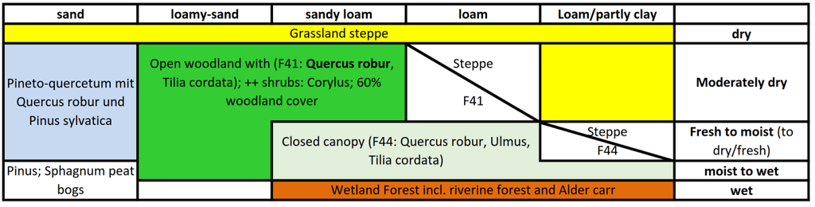

# Problem

- How to deal with the assumption of **different** climatic conditions?
- How to calculate with terms like **dry** or **wet**?

[figure not shown]

# FuzzyLandscapes

The [FuzzyLandscapes package](https://gitlab.com/CRC1266-A2/FuzzyLandscapes) enables the user to:

- Express fuzzy terms spatially by applying mathematical functions to crisp raster datasets
- Combine those fuzzy raster datasets by rule-based systems

# 1. Download of elevation information for specific region

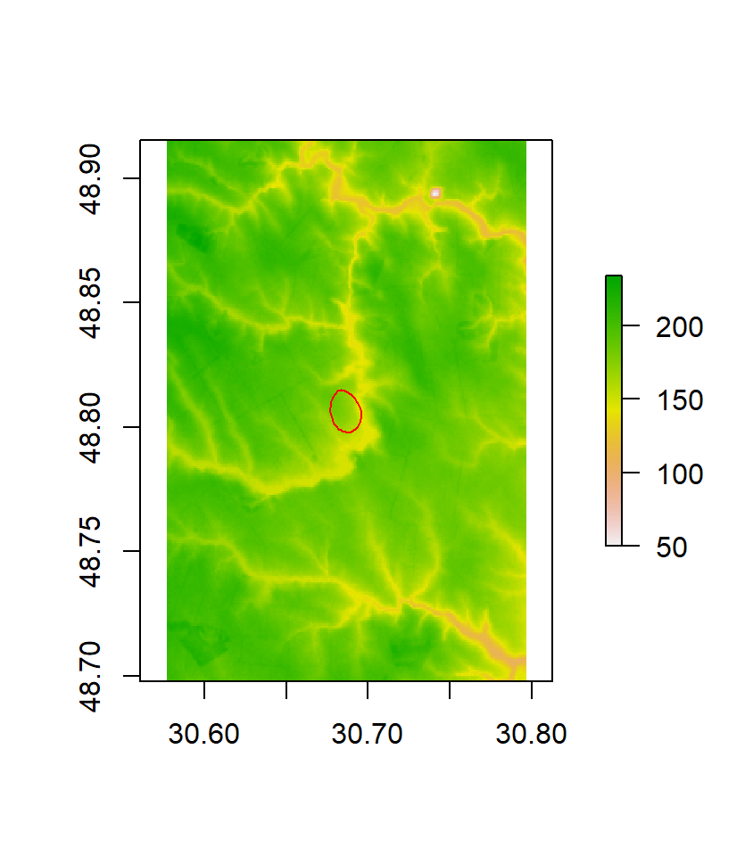

```r
library(raster)

Maidanetske <- readOGR(dsn = "./data/Megasites", layer = "Tripolye_mega-sites_polygons", verbose=FALSE) %>%
  spTransform(., CRS("+init=epsg:4326")) %>%
  '['(which(.@data$site=="Maidanetske"),)

srtm <- getData('SRTM',
                lon=mean(extent(Maidanetske)[c(1,2)]),
                lat=mean(extent(Maidanetske)[c(3,4)]))
plot(crop(srtm,extent(Maidanetske)+0.2))
lines(Maidanetske,col="red")
```

# 2. Derive information of elevation model

Using the package `RQGIS` to apply `saga:sagawetnessindex` to derive the potential wetness of the area

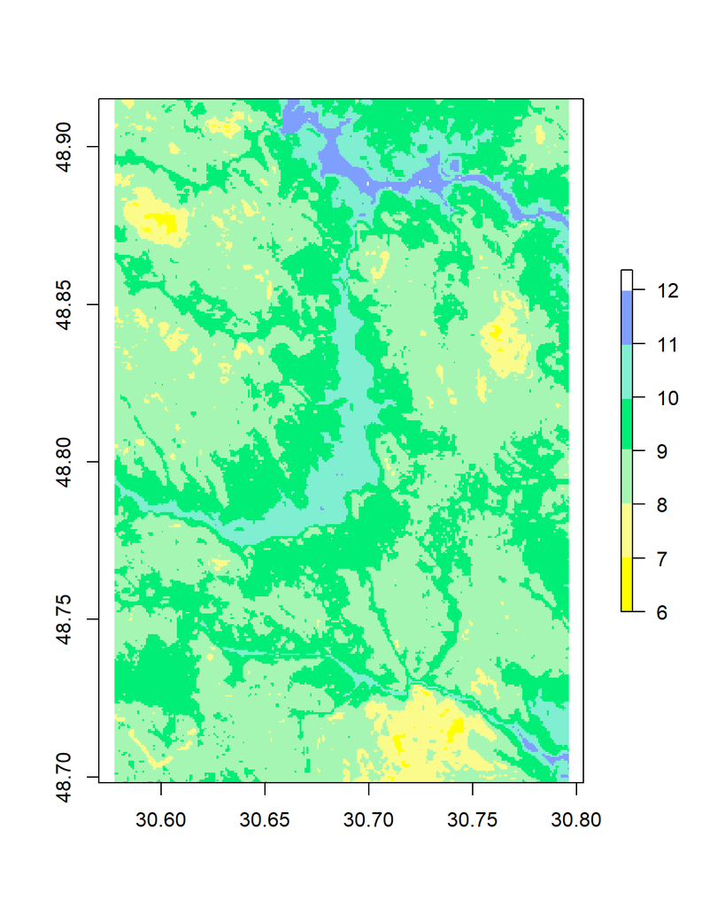

# 3. Download of soil data

- Download of sand, silt and clay content from the GlobalSoilGrid WCS Server

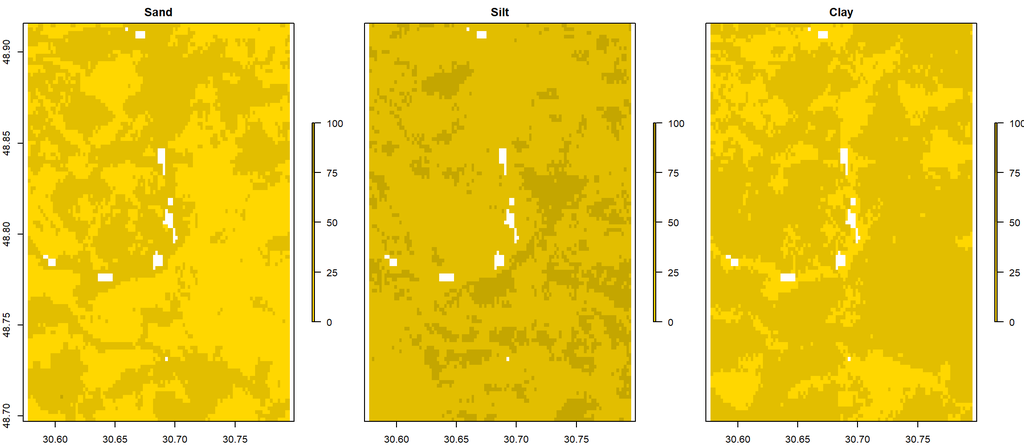

# 4. Fuzzification of the crisp data

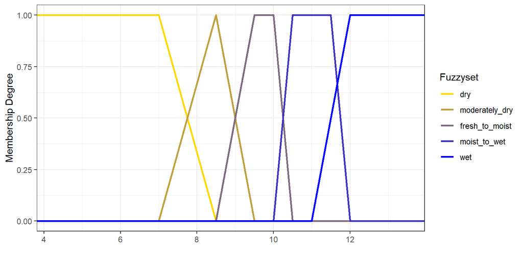

```r
library(FuzzyLandscapes)
dry <- fl_create_ras(method = "trapezoid",rast = swi,
                     p1=2,p2=3,p3=7,p4=8.5, setname = "dry")

moderately_dry <- fl_create_ras(method = "trapezoid",rast = swi,
                                         p1=7,p2=8.5,p3=8.5,p4=9.5, setname = "moderately_dry")

fresh_to_moist <- fl_create_ras(method = "trapezoid",rast = swi,
                                         p1=8.5,p2=9.5,p3=10,p4=10.5, setname = "fresh_to_moist")

moist_to_wet <- fl_create_ras(method = "trapezoid",rast = swi,
                                         p1=10,p2=10.5,p3=11.5,p4=12, setname = "moist_to_wet")

wet <- fl_create_ras(method = "trapezoid",rast = swi,
                                         p1=11,p2=12,p3=15,p4=16, setname = "wet")

plot_fs_comb(dry,moderately_dry,fresh_to_moist,moist_to_wet,wet,
             cols = colorRampPalette(c("gold","blue")))
```

# Fuzzified raster data

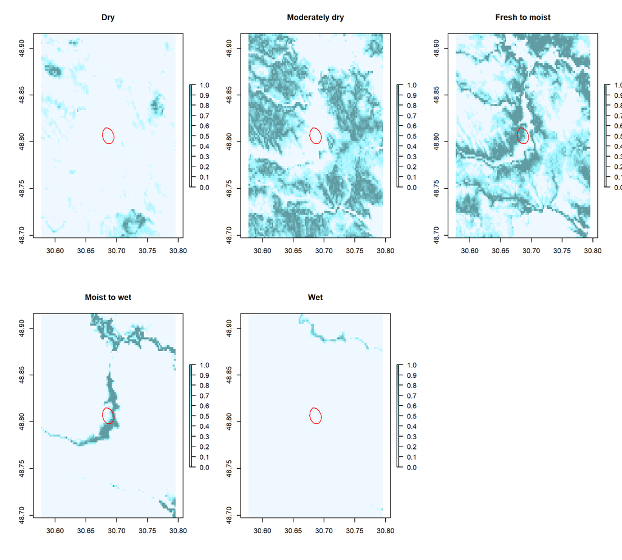

# 5. Definition of rules to combine the datasets

| Val1 | Op1 | Val2 | Op2 | Val3 | Op4 | Result |
| --- | --- | --- | --- | --- | --- | --- |
| sand_high | and | clay_low | and | silt_low | then | fine_sand |
| sand_high | and | clay_low | and | silt_medium | then | loamy_sand |
| sand_medium | and | clay_low | and | silt_medium | then | sandy_loam |
| sand_medium | and | clay_medium | and | silt_medium | then | loam |
| clay_medium | or | clay_high |  |  | then | medohigh_clay |
| sand_low | and | medohigh_clay | and | silt_medium | then | loam_partly_clay |
| dry |  |  |  |  | then | Grassland |
| moderately_dry | or | fresh_to_moist |  |  | then | dry_or_mod |
| dry_or_mod | and | fine_sand |  |  | then | Pineto_quercetum |
| dry_or_mod | and | loamy_sand |  |  | then | Open_woodland |
| moderately_dry | and | sandy_loam |  |  | then | Open_woodland |
| moderately_dry | and | loam |  |  | then | Open_woodland |
| loam | or | loam_partly_clay |  |  | then | loa_or_pac |
| moderately_dry | and | loa_or_pac |  |  | then | Grassland |
| loa_or_pac | or | sandy_loam |  |  | then | loa_pac_or_sa |
| fresh_to_moist | and | loa_pac_or_sa |  |  | then | Closed_canopy |
| fresh_to_moist | and | loam_partly_clay |  |  | then | Grassland |
| moist_to_wet | and | fine_sand |  |  | then | Pinus |
| moist_to_wet | and | loamy_sand |  |  | then | Open_woodland |
| moist_to_wet | and | loa_pac_or_sa |  |  | then | Closed_canopy |
| wet | and | fine_sand |  |  | then | Pinus |
| wet | and | loa_pac_or_sa |  |  | then | Alder_carr |

# 6. Application of defined rules on the fuzzified datasets

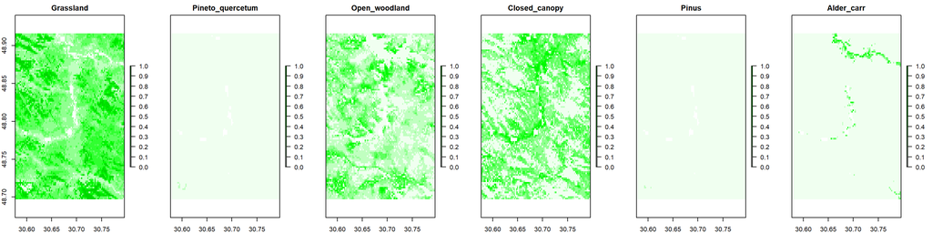

```r
whattodefuzz <- c("Grassland","Pineto_quercetum","Open_woodland","Closed_canopy","Pinus","Alder_carr")
fuzzystack <- fl_frbs_stack(sand_low,sand_medium,sand_high,
                            silt_low,silt_medium,silt_high,
                            clay_low,clay_medium,clay_high,
                            dry,moderately_dry,fresh_to_moist,moist_to_wet,wet,
                            rules = as.data.frame(ruleda),
                            result_intersect = TRUE,
                            defuzzification = whattodefuzz)
plot(crop(fuzzystack$FuzzyResults[[whattodefuzz]],extent(Maidanetske)+0.2),nc=6,breaks=seq(0,1,.1),col=colorRampPalette(c("honeydew","green","green3"))(11))
```

# Defuzzified classes

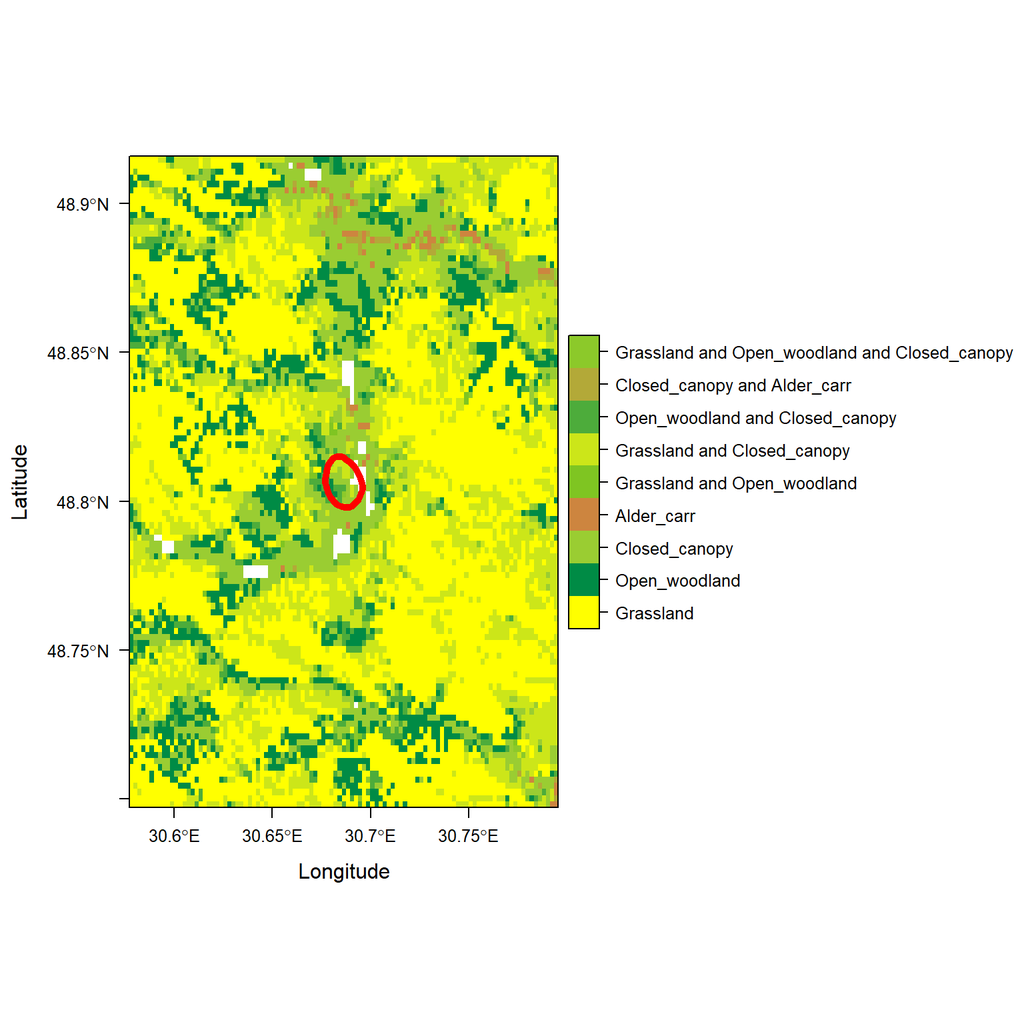

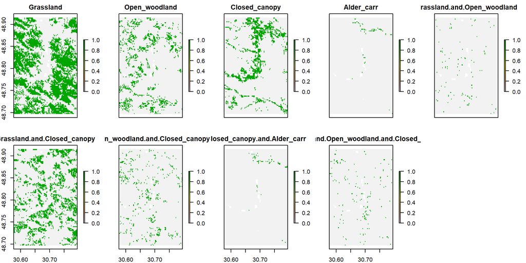

# Scenario Dry

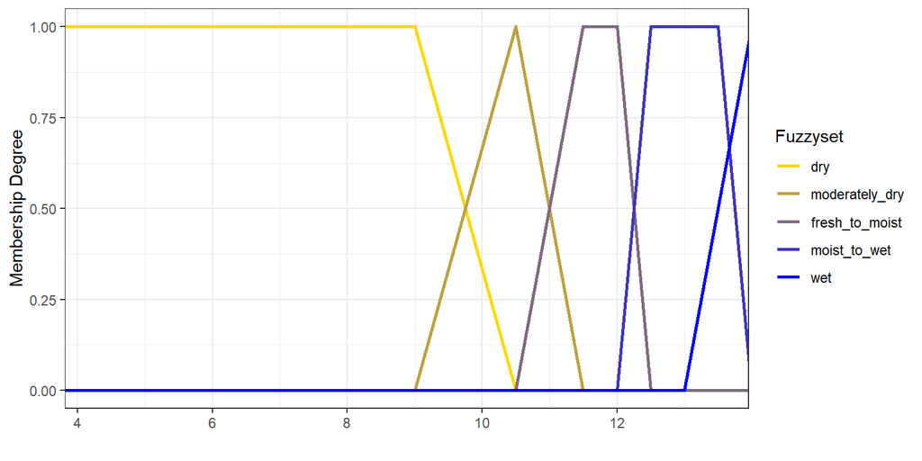

```r
changeby <- 2
dry <- fl_create_ras(method = "trapezoid",rast = swi,
                     p1=2,p2=3,p3=7+changeby,p4=8.5+changeby, setname = "dry")
moderately_dry <- fl_create_ras(method = "trapezoid",rast = swi,
                                p1=7+changeby,p2=8.5+changeby,p3=8.5+changeby,p4=9.5+changeby, setname = "moderately_dry")
fresh_to_moist <- fl_create_ras(method = "trapezoid",rast = swi,
                                p1=8.5+changeby,p2=9.5+changeby,p3=10+changeby,p4=10.5+changeby, setname = "fresh_to_moist")
moist_to_wet <- fl_create_ras(method = "trapezoid",rast = swi,
                              p1=10+changeby,p2=10.5+changeby,p3=11.5+changeby,p4=12+changeby, setname = "moist_to_wet")
wet <- fl_create_ras(method = "trapezoid",rast = swi,
                     p1=11+changeby,p2=12+changeby,p3=15+changeby,p4=16+changeby, setname = "wet")

plot_fs_comb(dry,moderately_dry,fresh_to_moist,moist_to_wet,wet,
             cols = colorRampPalette(c("gold","blue")))
```

# Scenario Wet

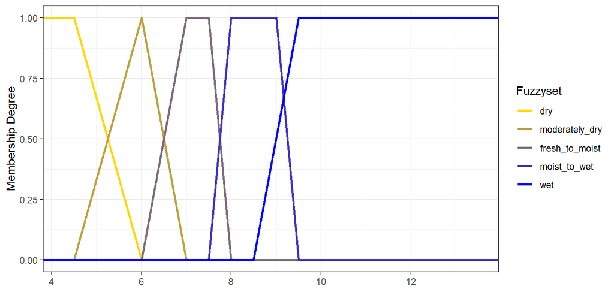

```r
changeby <- -2.5
dry <- fl_create_ras(method = "trapezoid",rast = swi,
                     p1=2+changeby,p2=3+changeby,p3=7+changeby,p4=8.5+changeby, setname = "dry")
moderately_dry <- fl_create_ras(method = "trapezoid",rast = swi,
                                p1=7+changeby,p2=8.5+changeby,p3=8.5+changeby,p4=9.5+changeby, setname = "moderately_dry")
fresh_to_moist <- fl_create_ras(method = "trapezoid",rast = swi,
                                p1=8.5+changeby,p2=9.5+changeby,p3=10+changeby,p4=10.5+changeby, setname = "fresh_to_moist")
moist_to_wet <- fl_create_ras(method = "trapezoid",rast = swi,
                              p1=10+changeby,p2=10.5+changeby,p3=11.5+changeby,p4=12+changeby, setname = "moist_to_wet")
wet <- fl_create_ras(method = "trapezoid",rast = swi,
                     p1=11+changeby,p2=12+changeby,p3=15,p4=16, setname = "wet")

plot_fs_comb(dry,moderately_dry,fresh_to_moist,moist_to_wet,wet,
             cols = colorRampPalette(c("gold","blue")))
```

# Results

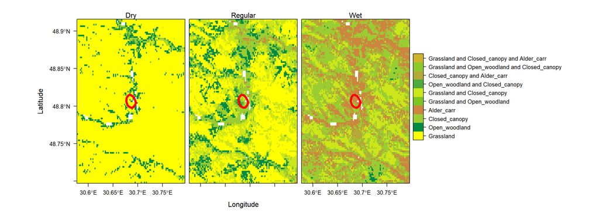

# Outlook

Next steps:

- Implementation of distance to settlement?
- Calculation of wood amount produced by area?
- Including data with higher spatial resoulution?

# Conclusion

FuzzyLandscapes allows working with fuzzy terms like *high*, *low*, *close*, *far*, *steep* or *flat* by

- Fuzzification of crisp raster data
- Rule-based combination of fuzzy datasets
- Defuzzification of those combined datasets

Try it out in your specific field and let us know about your experience with FuzzyLandscapes (https://gitlab.com/CRC1266-A2/FuzzyLandscapes)

[figure not shown]

# Acknowledgements

Thanks to the CRC 1266 - Scales of Transformations

[figure not shown]